# hw4

      ::: {.cell}

      ```sas
      proc sql;
          create table StatePercentRecords as
          select
              state_name,
              (sum(nweight) / (select sum(nweight) from work.recs)) * 100 as record_percent
          from work.recs
          group by state_name;
      quit;

      proc sort data=StatePercentRecords;
          by descending record_percent;
      run;

      proc print data=StatePercentRecords (obs=1);
      run;

      proc sql;
          create table MichiganStatePercentRecords as
          select * from StatePercentRecords
          where state_name = 'Michigan';
      quit;

      proc print data=MichiganStatePercentRecords;
      run;
      ```

      :::

      ::: {.cell}

      ```sas
      proc sql;
          create table ElectricityCost as
          select DOLLAREL, log(DOLLAREL) as log_dollarel from work.recs
          where DOLLAREL > 0;
      quit;

      proc sgplot data=ElectricityCost;
          histogram DOLLAREL / binwidth=100;
          xaxis grid;
          yaxis grid;
          xaxis label="Cost in Dollars for Electricity";
          yaxis label="Frequency";
      run;
      ```

      :::

      ::: {.cell}

      ```sas
      proc sql;
          create table ElectricityCost as
          select DOLLAREL, log(DOLLAREL) as log_dollarel from work.recs
          where DOLLAREL > 0;
      quit;

      proc sgplot data=ElectricityCost;
          histogram log_dollarel / binwidth=.1;
          xaxis grid;
          yaxis grid;
          xaxis label="Log Cost in Dollars for Electricity";
          yaxis label="Frequency";
      run;
      ```

      :::

      ::: {.cell}

      ```sas
      proc sql;
          create table ModelData as
          select (TOTROOMS + NCOMBATH + NHAFBATH) as tot_rooms,
              PRKGPLC1,
              NWEIGHT,
              DOLLAREL as dollarel,
              log(DOLLAREL) as log_dollarel
          from work.recs
          where PRKGPLC1 <> -2;
      quit;

      data ModelData;
          set ModelData;
          if not missing(tot_rooms) and not missing(PRKGPLC1);
          if not missing(NWEIGHT) and not missing(dollarel);
          if not missing(log_dollarel);
      run;
      proc reg data=ModelData;
          model log_dollarel = tot_rooms PRKGPLC1;
          output out=ModelData predicted=pred_log_dollarel;
          weight NWEIGHT;
      run;
      ```

      :::

      ::: {.cell}

      ```sas
      data ModelData;
          set ModelData;
          pred_dollarel = exp(pred_log_dollarel);
      run;

      proc sgplot data=ModelData;
          scatter x=dollarel y=pred_dollarel;
          xaxis label="Actual Cost in Dollars for Electricity";
          yaxis label="Predicted Cost in Dollars for Electricity";
      run;
      ```

      :::

      ::: {.cell}

      ```sas
      proc import
      datafile="~/sasuser.v94/public2022.csv"
      out=data;

      proc sql;
          create table SubsetData as
          select
              B3 as better_same_worse,
              ND2 as natural_disaster,
              B7_b as economic_today,
              GH1 as home_owner_status,
              ppeducat as education,
              race_5cat as race
          from data;
      quit;

      proc export data=SubsetData
          outfile="~/sasuser.v94/public2022.dta"
          dbms=STATA replace;
      run;
      ```

      :::
   2. Demonstrate that you’ve successfully extracted the appropriate data by showing the number of observations and variables.

      ::: {.cell}

      ```stata
      use "\\tsclient\Remote Desktop Virtual Drive\Uploads\public2022.dta"
      describe
      ```

      :::

      Observations: 11,667  
      Variables: 8  
      CaseID double %12.0g better_worse double %12.0g nat_dis double %12.0g econ_tdy double %12.0g home double %12.0g education double %12.0g race double %12.0g weight double %12.0g

      There were 11,667 observations in the dataset which means we have successfully extracted the data.
   3. Carry out a logisitic regression model accounting for the complex survey design.

      ::: {.cell}

      ```stata
      svyset CaseID [pw=weight]
      svy: logistic better_worse nat_dis econ_tdy i.education i.home i.race
      ```

      :::

      Sampling weights: weight  
      VCE: linearized  
      Single unit: missing  
      Strata 1:  
      Sampling unit 1: CaseID  
      FPC 1:

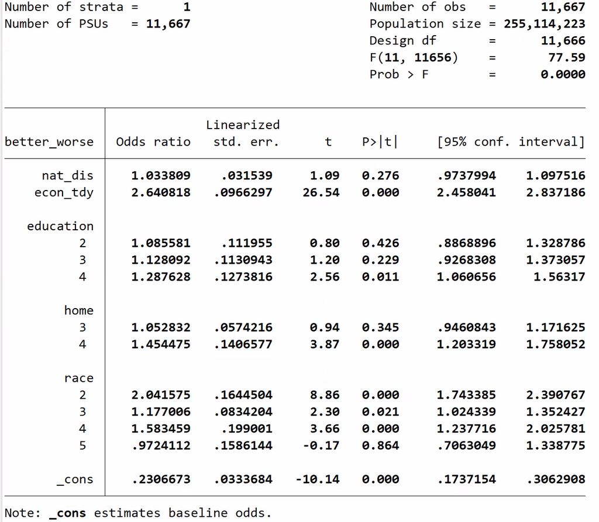

      Given that the odds ratio for nat_dis is 1.033 controlling for all other variables, that means that if someone thinks that the chance of a natural disaster is low, then they are 1.033 times more likely to think that the economy will be better. However, there is a p value of .276 which means that the variable itself is not statistically significant and consequently would not be a good predictor.
   4. Use the survey package to obtain the pseudo-R^2 value

      ::: {.cell}

      ```r
      library(survey)
      ```

      ::: {.cell-output .cell-output-stderr} ```

      ```
      :::

      ::: {.cell-output .cell-output-stderr}
      ```

      ::: {.cell-output .cell-output-stderr} ```

      ```{.r .cell-code}
      library(haven)
      dat <- read_dta("public2022.dta")
      des <- svydesign(id = ~ CaseID, weight = ~ weight, data = dat)
      model <- svyglm(better_worse ~ nat_dis + econ_tdy + education + as.factor(home) + as.factor(race), design = des, family = quasibinomial)
      print(psrsq(model))
      ````

      ::: {.cell-output .cell-output-stdout} `[1] 0.1072836` ::: :::